# A Vocabulary of Marks

1. The choice of encodings can have a strong effect on (1) the types of comparisons that a visualization suggests and (2) the chance that readers leave with complete and accurate conclucions. With this in mind, it’s worthwhile to develop a rich vocabulary of potential visual encodings.
2. So, let’s look at a few different types of encodings available in `ggplot2`. Before we get started, let’s load up the libraries that will be used in these notes. `ggplot2` is our plotting library. `readr` is used to read data files from a web link, and `dplyr` is useful for some of the data manipulations below.

```r
library(readr)
library(ggplot2)
library(scales)
library(dplyr)
theme_set(theme_bw()) # instead of adding `+ theme_bw()` to each plot, we can just set it as the default theme for this R session
```

# Point Marks

3. Let’s read in the gapminder dataset, which describes the changes in standard of living around the world over the last few decades. The `%>%` “pipe” operator takes the output of the previous command as input to the next one – it is useful for chains of commands where the intermediate results are not needed. The `mutate` command makes sure that the country group variable is treated as a categorical, and not numeric, variable.

```r
gapminder <- read_csv("https://uwmadison.box.com/shared/static/dyz0qohqvgake2ghm4ngupbltkzpqb7t.csv", col_types = cols()) %>%
  mutate(cluster = as.factor(cluster))  # specify that cluster is nominal
gap2000 <- filter(gapminder, year == 2000) # keep only year 2000
```

4. Point marks can encode data fields using their $x$ and $y$ positions, color, size, and shape. Below, each mark is a country, and we’re using shape and the $y$ position to distinguish between country clusters.

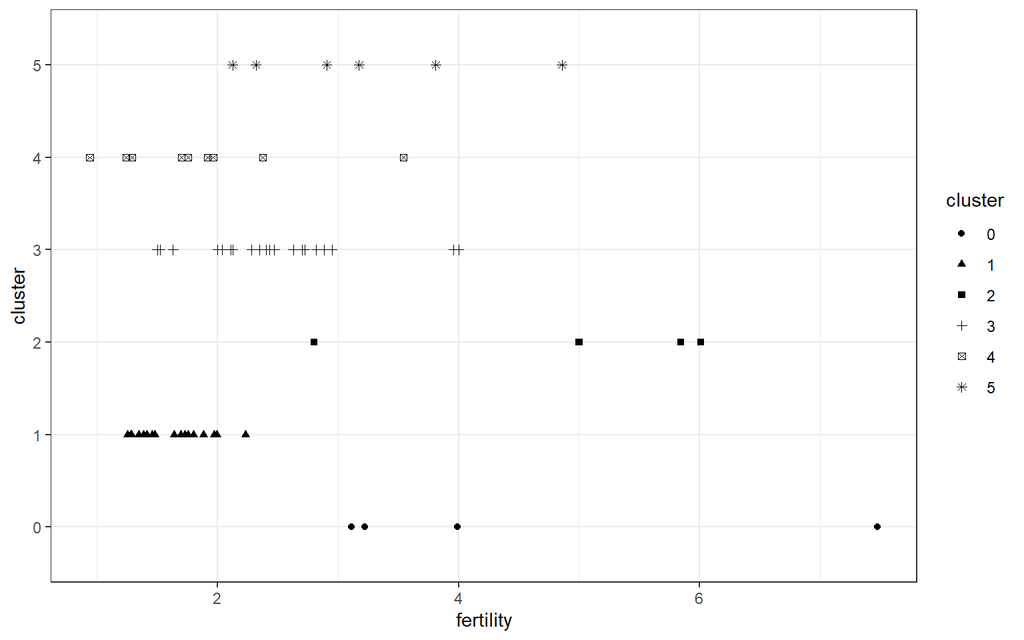

```r
ggplot(gap2000) +
  geom_point(aes(x = fertility, y = cluster, shape = cluster))
```

Since the first two arguments in `aes` are always the `x` and `y` positions, we can omit it from our command. The code below produces the exact same plot (try it!).

```r
ggplot(gap2000) +
  geom_point(aes(fertility, cluster, shape = cluster))
```

5. We can specify different types of shapes using the `shape` parameter outside of the `aes` encoding.

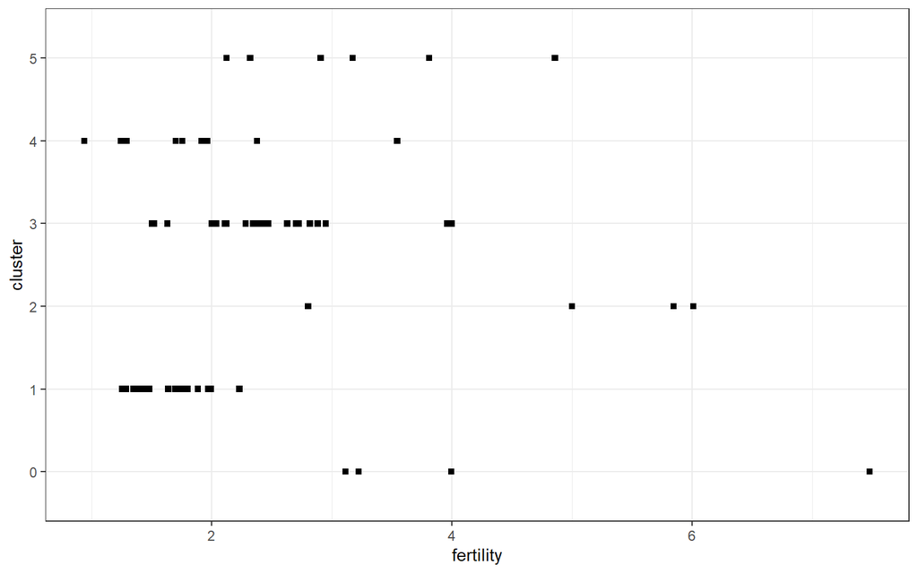

```r
ggplot(gap2000) +
  geom_point(aes(fertility, cluster), shape = 15)
```

# Bar Marks

6. Bar marks let us associate a continuous field with a nominal one.

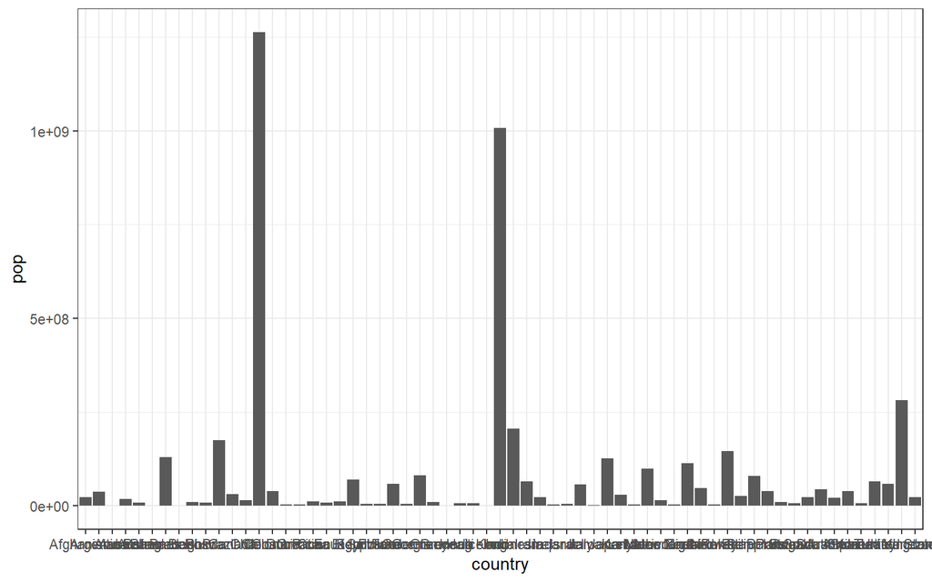

```r
ggplot(gap2000) +
  geom_bar(aes(country, pop), stat = "identity")
```

The plot above is messy – it would not be appropriate for a publication or presentation. The grid lines associated with each bar are distracting. Further, the axis labels are all running over one another. For the first issue, we can customize the `theme` of the plot. Note that we don’t have to memorize the names of these arguments, since they should autocomplete when pressing tab (we just need to memorize the first few letters).

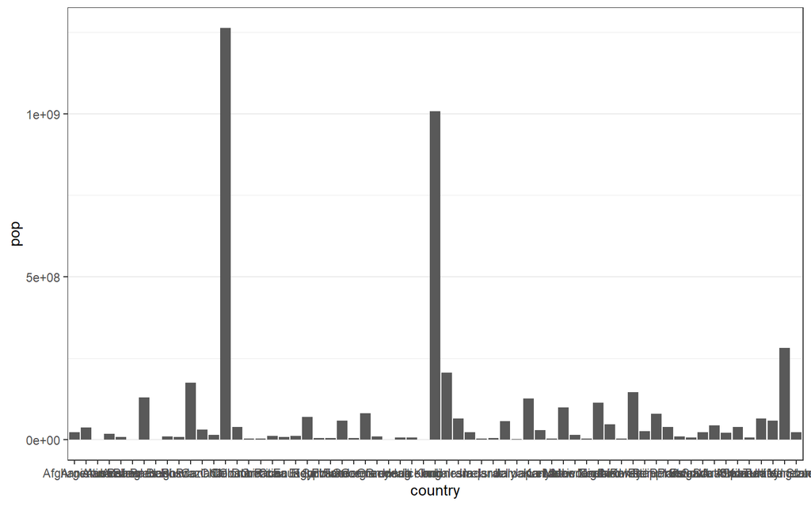

```r
ggplot(gap2000) +
  geom_bar(aes(country, pop), stat = "identity") +
  theme(panel.grid.major.x = element_blank())
```

For the second issue, one approach is to turn the labels on their side, again by customizing the theme.

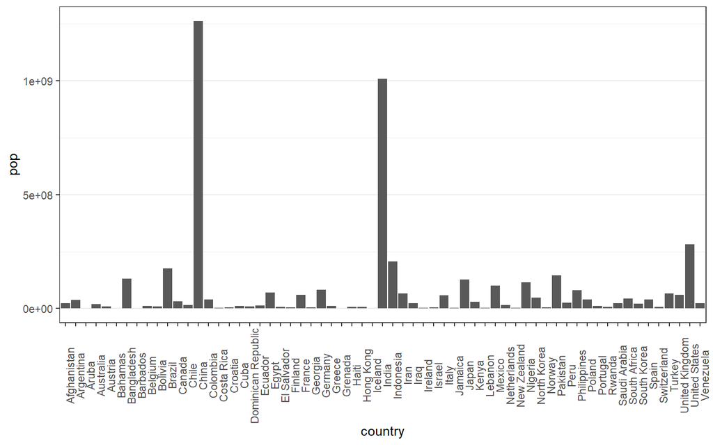

```r
ggplot(gap2000) +
  geom_bar(aes(country, pop), stat = "identity") +
  theme(
    axis.text.x = element_text(angle = 90),
    panel.grid.major.x = element_blank()
  )
```

An approach I like better is to turn the bars on their side. This way, readers don’t have to tilt their heads to read the country names.

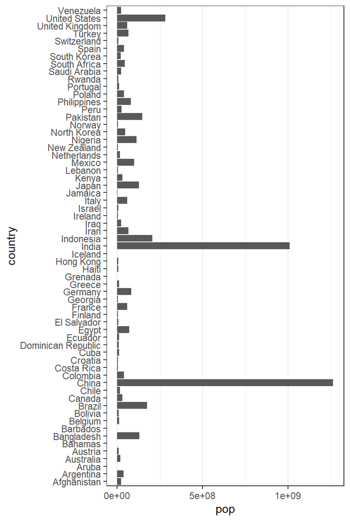

```r
ggplot(gap2000) +
  geom_bar(aes(pop, country), stat = "identity") +
  theme(panel.grid.major.y = element_blank()) # note change from x to y
```

I’m also going to remove the small tick marks associated with every name, again because it seems distracting.

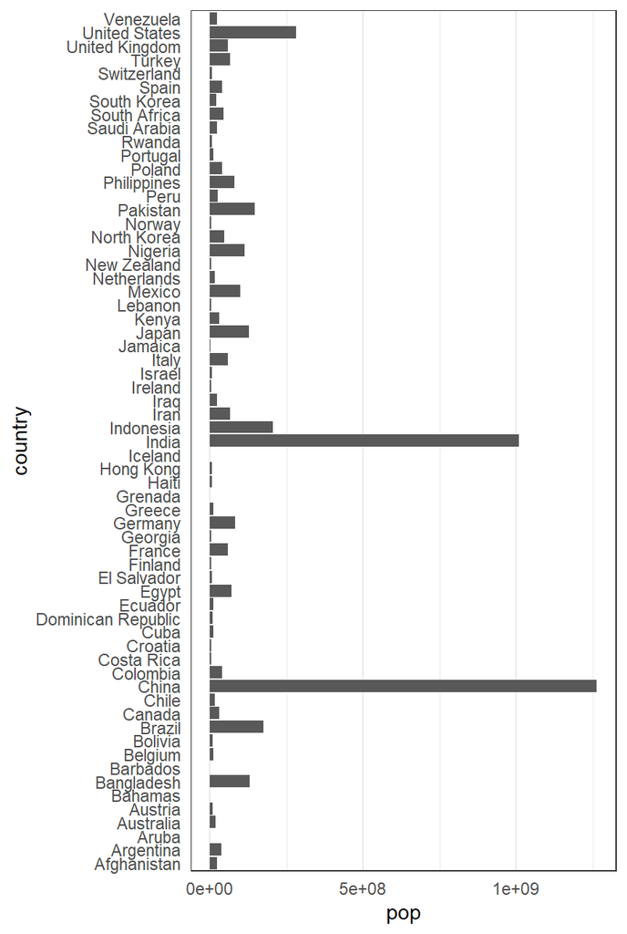

```r
ggplot(gap2000) +
  geom_bar(aes(pop, country), stat = "identity") +
  theme(
    panel.grid.major.y = element_blank(),
    axis.ticks = element_blank() # remove tick marks
  )
```

7. To make comparisons between countries with similar populations easier, we can order them by population (alphabetical ordering is not that meaningful). To compare clusters, we can color in the bars.

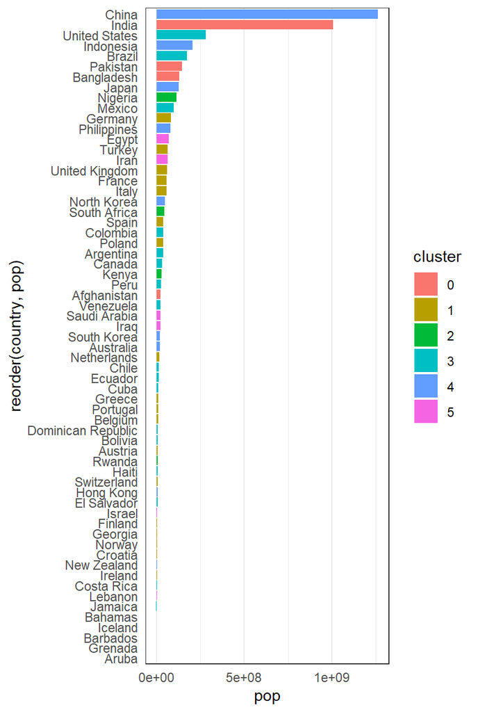

   ```r
   ggplot(gap2000) +
     geom_bar(aes(pop, reorder(country, pop), fill = cluster), stat = "identity") +
     theme(
       axis.ticks = element_blank(),
       panel.grid.major.y = element_blank()
     )
   ```

8. We’ve been spending a lot of time on this plot. This is because I want to emphasize that a visualization is not just something we can get just by memorizing some magic (programming) incantation. Instead, it is something worth critically engaging with and refining, in a similar way that we would refine an essay or speech.

   Philosophy aside, there are still a few points that need to be improved in this figure,
   - The axis titles are not meaningful.
   - There is a strange gap between the left hand edge of the plot and the start of the bars.
   - I would also prefer if the bars were exactly touching one another, without the small vertical gap.
   - The scientific notation for population size is unnecessarily technical.
   - The color scheme is a bit boring.

   I’ll address each of these in a separate code block, with comments on the parts that are different. First, improving the axis titles,

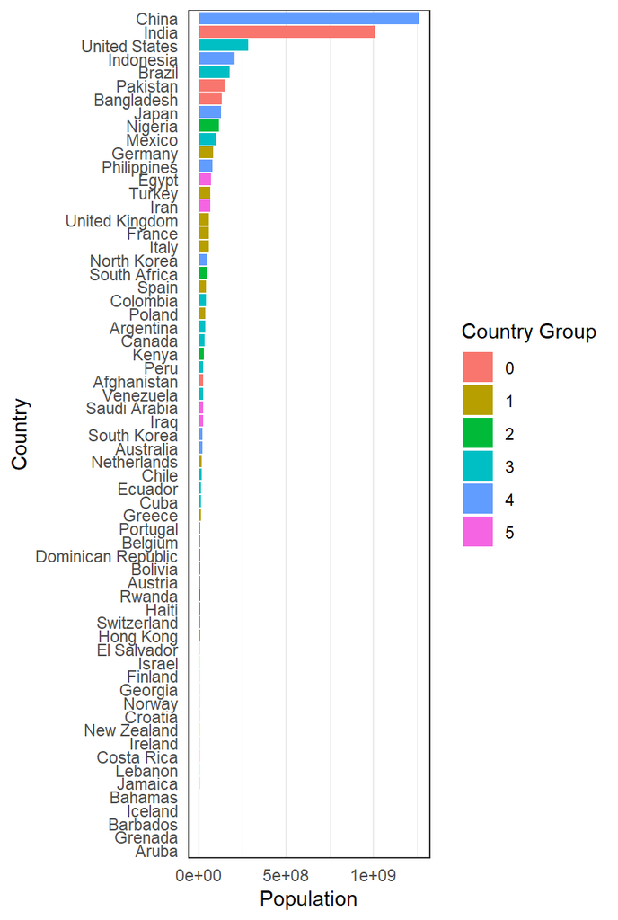

   ```r
   ggplot(gap2000) +
     geom_bar(aes(pop, reorder(country, pop), fill = cluster), stat = "identity") +
     labs(x = "Population", y = "Country", fill = "Country Group") + # add better titles
     theme(
       axis.ticks = element_blank(),
       panel.grid.major.y = element_blank()
     )
   ```

   Now we remove the gap. I learned this trick by [googling it](https://stackoverflow.com/questions/22945651/remove-space-between-plotted-data-and-the-axes) – there is no shame in doing this! A wise friend of mine [SU25 Cameron clarification: This is Professor Kris Sankaran’s writing!] once shared, “I am not a programming expert, just an expert at StackOverflow.”

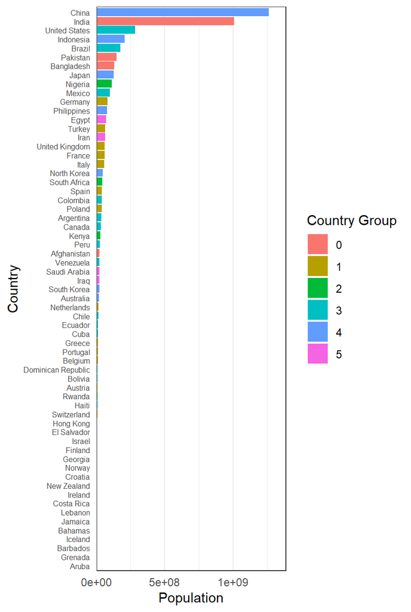

   ```r
   ggplot(gap2000) +
     geom_bar(aes(pop, reorder(country, pop), fill = cluster), stat = "identity") +
     scale_x_continuous(expand = c(0, 0, 0.1, 0.1)) + # remove space to the axis
     labs(x = "Population", y = "Country", fill = "Country Group") +
     theme(
       axis.text.y = element_text(size = 6),
       axis.ticks = element_blank(),
       panel.grid.major.y = element_blank()
     )
   ```

   Now, removing the gaps between bars.

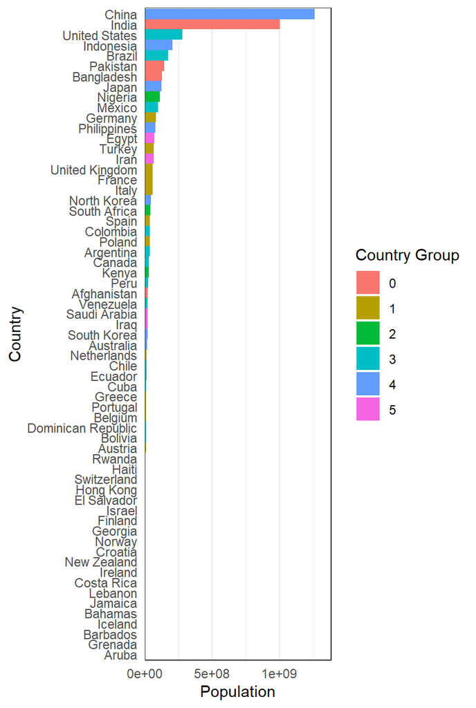

   ```r
   ggplot(gap2000) +
     geom_bar(
       aes(pop, reorder(country, pop), fill = cluster),
       width = 1, stat = "identity" # increase width of bars
     ) +
     scale_x_continuous(expand = c(0, 0, 0.1, 0.1)) +
     labs(x = "Population", y = "Country", fill = "Country Group", color = "Country Group") +
     theme(
       axis.ticks = element_blank(),
       panel.grid.major.y = element_blank()
     )
   ```

   Now, we remove scientific notation,

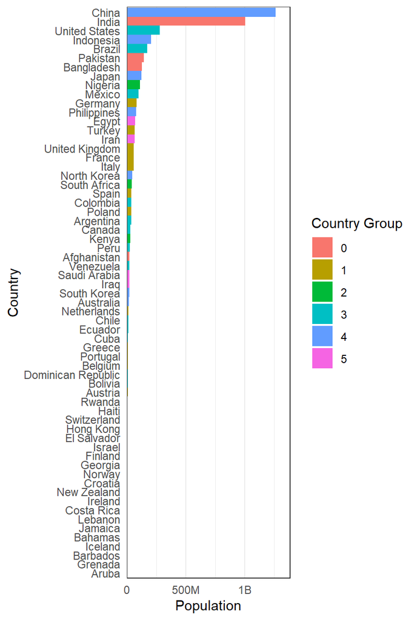

   ```r
   ggplot(gap2000) +
     geom_bar(
       aes(pop, reorder(country, pop), fill = cluster),
       width = 1, stat = "identity"
     ) +
     scale_x_continuous(label = label_number(scale_cut = cut_short_scale()), expand = c(0, 0, 0.1, 0.1)) + # remove scientific notation. scales::comma() is also useful.
     labs(x = "Population", y = "Country", fill = "Country Group", color = "Country Group") +
     theme(
       axis.ticks = element_blank(),
       panel.grid.major.y = element_blank()
     )
   ```

   Finally, we customize the colors. I often like to look up neat colors on [color.adobe.com](https://color.adobe.com/), [iwanthue](https://medialab.github.io/iwanthue/) or [colorhexa](https://www.colorhexa.com/), but there are dozens of similar colorpicker sites out there.

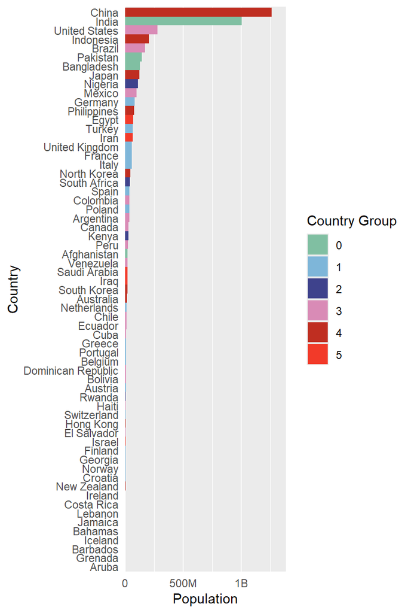

   ```r
   ggplot(gap2000) +
     geom_bar(
       aes(pop, reorder(country, pop), fill = cluster),
       width = 1, stat = "identity"
     ) +
     scale_x_continuous(label = label_number(scale_cut = cut_short_scale()), expand = c(0, 0, 0.1, 0.1)) +
     scale_fill_manual(values = c("#80BFA2", "#7EB6D9", "#3E428C", "#D98BB6", "#BF2E21", "#F23A29")) +
     labs(x = "Population", y = "Country", fill = "Country Group", color = "Country Group") +
     theme(
       axis.ticks = element_blank(),
       panel.grid.major.y = element_blank()
     )
   ```

9. This seems like a lot of work for just a lowly bar plot! But I think it’s amazing customizable the figure is – we can give it our own sense of style. With a bit of practice, these sorts of modifications will become second nature, and it won’t be necessary to keep track of all the intermediate code. And really, even though we spent some time on this plot, there are still many things that could be interesting to experiment with, like font styles, background appearance, maybe even splitting the countries into two panels.
10. In the plot above, each bar is anchored at 0. Instead, we could have each bar encode *two* continuous values, a left and right. To illustrate, let’s compare the minimum and maximimum life expectancies within each country cluster. We’ll need to create a new `data.frame` with just the summary information. For this, we `group_by` each cluster, so that a `summarise` call finds the minimum and maximum life expectancies restricted to each cluster.

    ```r
    # find summary statistics
    life_ranges <- gap2000 %>%
      group_by(cluster) %>%
      summarise(
        min_life = min(life_expect),
        max_life = max(life_expect)
      )

    # look at a few rows
    head(life_ranges)
    ```

    ```
    ## # A tibble: 6 × 3
    ##   cluster min_life max_life
    ##   <fct>      <dbl>    <dbl>
    ## 1 0           42.1     63.6
    ## 2 1           70.5     80.6
    ## 3 2           43.4     53.4
    ## 4 3           58.1     79.8
    ## 5 4           66.7     82
    ## 6 5           57.0     79.7
    ```

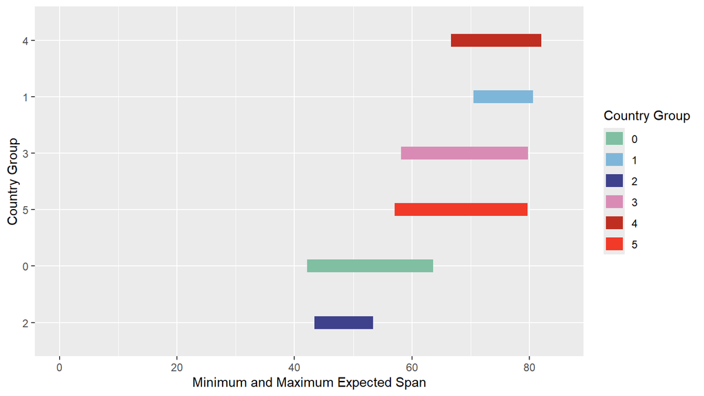

    ```r
    ggplot(life_ranges) +
      geom_segment(
        aes(min_life, reorder(cluster, max_life), xend = max_life, yend = cluster, col = cluster),
        size = 5,
      ) +
      scale_color_manual(values = c("#80BFA2", "#7EB6D9", "#3E428C", "#D98BB6", "#BF2E21", "#F23A29")) +
      labs(x = "Minimum and Maximum Expected Span", col = "Country Group", y = "Country Group") +
      xlim(0, 85) # otherwise would only range from 42 to 82
    ```

# Line Marks

11. Line marks are useful for comparing changes. Our eyes naturally focus on rates of change when we see lines. Below, we’ll plot the fertility over time, colored in by country cluster. The `group` argument is useful for ensuring each country gets its own line; if we removed it, `ggplot2` would become confused by the fact that the same `x` (year) values are associated with multiple `y`’s (fertility rates).

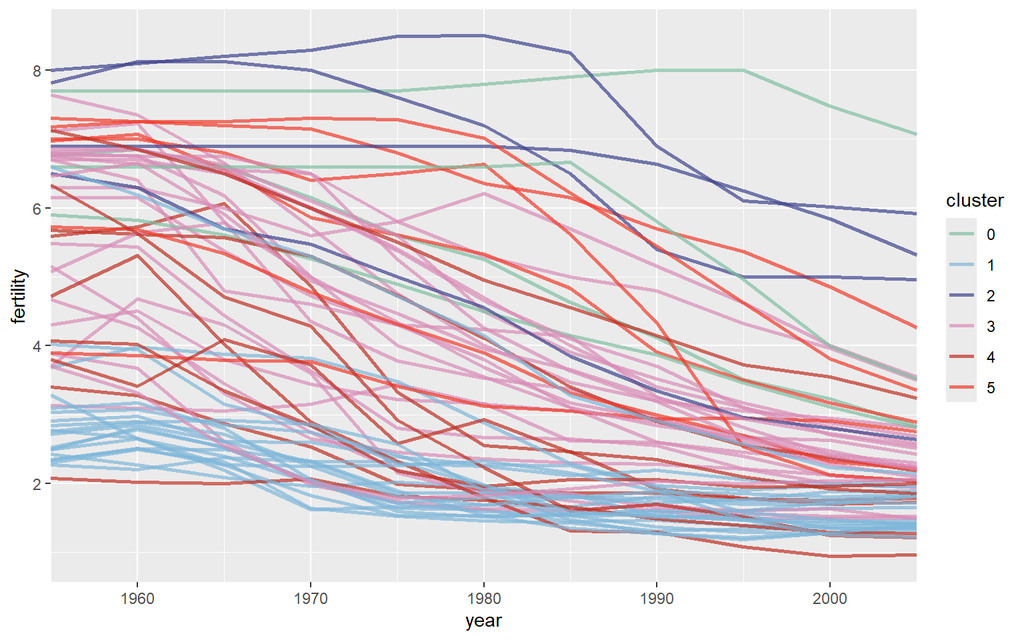

    ```r
    ggplot(gapminder) +
      geom_line(
        aes(year, fertility, col = cluster, group = country),
          alpha = 0.7, size = 0.9
      ) +
      scale_x_continuous(expand = c(0, 0)) +  # same trick of removing gap
      scale_color_manual(values = c("#80BFA2", "#7EB6D9", "#3E428C", "#D98BB6", "#BF2E21", "#F23A29"))
    ```

# Area Marks

12. Area marks have a flavor of both bar and line marks. The filled area supports absolute comparisons, while the changes in shape suggest derivatives.

    ```r
    population_sums <- gapminder %>%
      group_by(year, cluster) %>%
      summarise(total_pop = sum(pop))
    head(population_sums)
    ```

    ```
    ## # A tibble: 6 × 3
    ## # Groups:   year [1]
    ##    year cluster total_pop
    ##   <dbl> <fct>       <dbl>
    ## 1  1955 0       495927174
    ## 2  1955 1       360609771
    ## 3  1955 2        60559800
    ## 4  1955 3       355392405
    ## 5  1955 4       854125031
    ## 6  1955 5        56064015
    ```

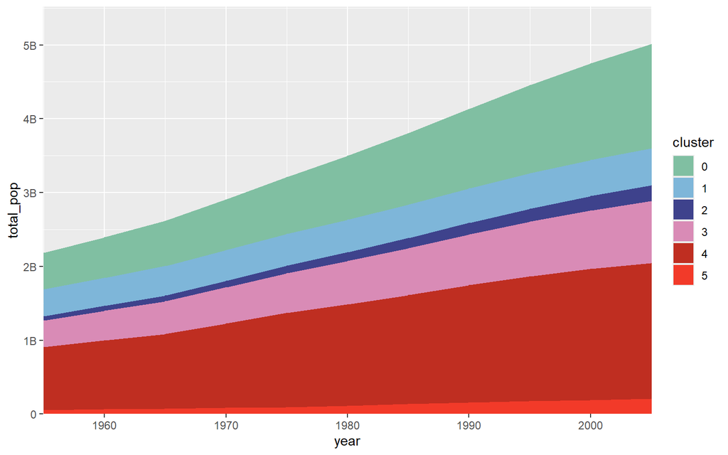

    ```r
    ggplot(population_sums) +
      geom_area(aes(year, total_pop, fill = cluster)) +
      scale_y_continuous(expand = c(0, 0, .1, .1), label = label_number(scale_cut = cut_short_scale())) +
      scale_x_continuous(expand = c(0, 0)) +
      scale_fill_manual(values = c("#80BFA2", "#7EB6D9", "#3E428C", "#D98BB6", "#BF2E21", "#F23A29"))
    ```

    Just like in bar marks, we don’t necessarily need to anchor the $y$-axis at 0. For example, here the bottom and top of each area mark is given by the 30% and 70% quantiles of population within each country cluster.

    ```r
    population_ranges <- gapminder %>%
      group_by(year, cluster) %>%
      summarise(min_pop = quantile(pop, 0.3), max_pop = quantile(pop, 0.7))
    head(population_ranges)
    ```

    ```
    ## # A tibble: 6 × 4
    ## # Groups:   year [1]
    ##    year cluster   min_pop   max_pop
    ##   <dbl> <fct>       <dbl>     <dbl>
    ## 1  1955 0       40880121. 83941368.
    ## 2  1955 1        4532940  25990229.
    ## 3  1955 2        6600426. 17377594.
    ## 4  1955 3        2221139   8671500
    ## 5  1955 4        9014491  61905422
    ## 6  1955 5        3007625  12316126.
    ```

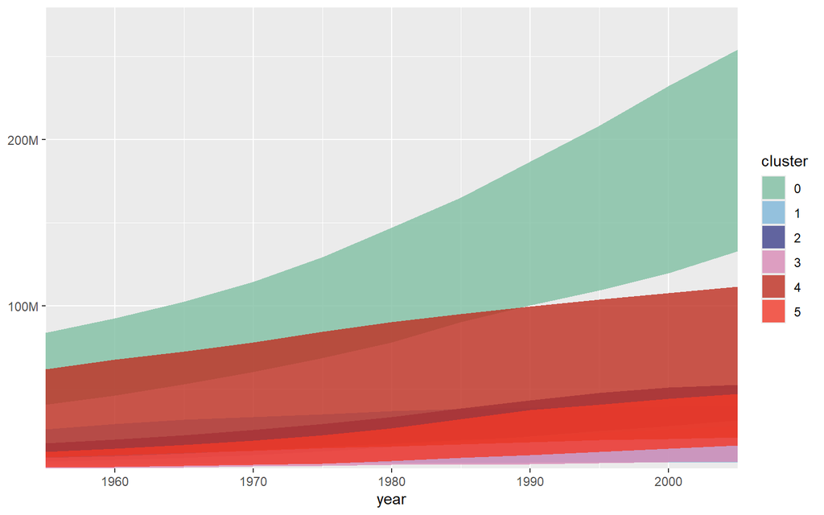

    ```r
    ggplot(population_ranges) +
      geom_ribbon(
        aes(x = year, ymin = min_pop, ymax = max_pop, fill = cluster),
        alpha = 0.8
      ) +
      scale_y_continuous(expand = c(0, 0, .1, .1), label = label_number(scale_cut = cut_short_scale())) +
      scale_x_continuous(expand = c(0, 0)) +
      scale_fill_manual(values = c("#80BFA2", "#7EB6D9", "#3E428C", "#D98BB6", "#BF2E21", "#F23A29"))
    ```

# Beyond The Built-Ins

`ggplot2` has more available `geom`s than what we’ve gone over today - we encourage you to explore them! As mentioned in the previous lecture, you can see all the built in of `geoms` in the [cheat sheet](https://github.com/rstudio/cheatsheets/blob/master/data-visualization-2.1.pdf).

Because `ggplot2` is [so popular](https://www.datasciencemeta.com/rpackages), many specialized visualization packages in R use the same conventions and specifically make their `geoms` friendly with other `ggplot2` commands.

You can see a full gallery of “registered” community extensions to `ggplot2` [here](https://exts.ggplot2.tidyverse.org/gallery/), and we’ll show two examples here. There are plenty more unregistered examples that are just as useful, and I’ll show one example below.

These examples are excellent evidence that slight deviations from the basic `geom`s you’re used to *can* be extremely effective.

## ggridges

**Problem**: Comparing the shapes of overlapping density plots can be difficult when there are more than a few plots…

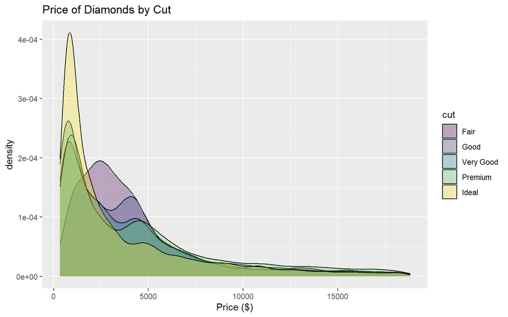

```r
ggplot(diamonds) +
  geom_density(aes(price, fill = cut), alpha = 0.3) +

  labs(
    x = "Price ($)",
    title = "Price of Diamonds by Cut"
  )
```

… and faceting makes vertical comparisons at the same point much harder, especially for panels in different columns.

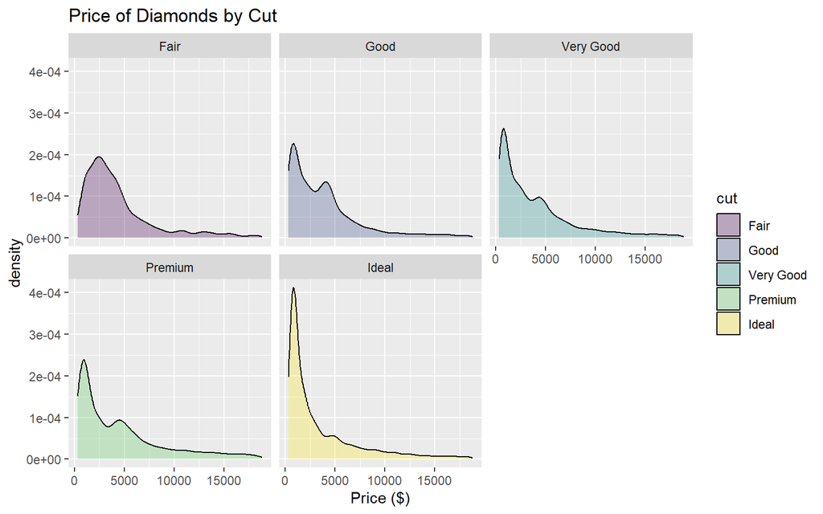

```r
ggplot(diamonds) +
  geom_density(aes(price, fill = cut), alpha = 0.3) +
  facet_wrap(~cut) +

  labs(
    x = "Price ($)",
    title = "Price of Diamonds by Cut"
  )
```

**Solution**: Ridge plots, with `ggridges`!

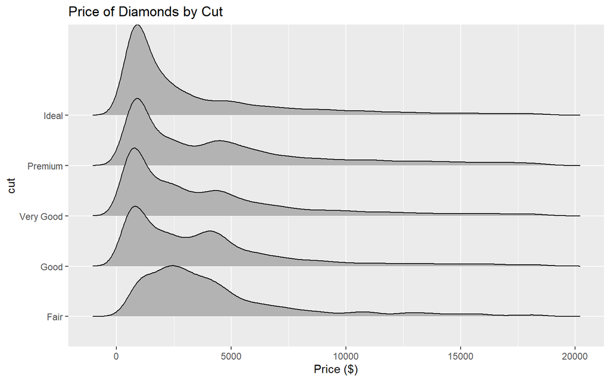

```r
library(ggridges)
ggplot(diamonds) +
  geom_density_ridges(aes(price, cut)) + # Notice how the same fundamentals of ggplot aesthetics makes this function very natural to use! That's on purpose!

  labs(
    x = "Price ($)",
    title = "Price of Diamonds by Cut"
  )
```

This configuration draws on viewers’ intuitive understanding of density plots, and simultaneously enabling both comparisons that overlapping/faceting plots might struggle with:

- Observing the individual structure of a single density plot within a `cut`
- Making comparisons of the density at a single price point across `cut`s

*I [Cameron] think viewer’s intuitive understanding of density plots is very interesting. Density is a pretty mathematical concept under the hood, and interpretation of a specific point on the curve is not easy. However, people are able to make meaningful conclusions about the overall shape without any of those details!*

## ggbeeswarm

**Problem:** When the viewer has intuitive familiarity with what each observation represents in a small dataset being visualized, they want the plot to connect to their understanding of the raw data. However, plots that rely on mathematical summaries like density curves, boxplots, or histograms, put some cognitive work in between the viewer and their understanding of the data. This is the opposite of what a visualization is supposed to do.

```r
# When one observation in the dataset is a state...
library(dslabs)
head(murders)
```

```
##        state abb region population total
## 1    Alabama  AL  South    4779736   135
## 2     Alaska  AK   West     710231    19
## 3    Arizona  AZ   West    6392017   232
## 4   Arkansas  AR  South    2915918    93
## 5 California  CA   West   37253956  1257
## 6   Colorado  CO   West    5029196    65
```

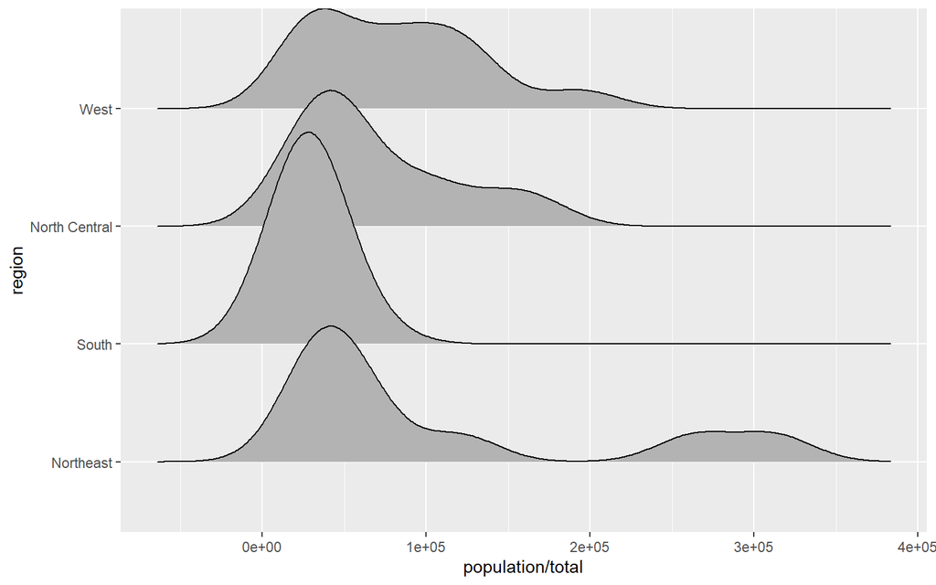

```r
# ...viewers are expecting each mark on the graph to represent a state! (Fill in the blank with whatever your visualization interest is; sports teams/players, months of the year, Fortune 500 companies...)

# However, these mathematical transformations don't satisfy that desired property.

ggplot(murders) +
  geom_density_ridges(aes(population/total, region))
```

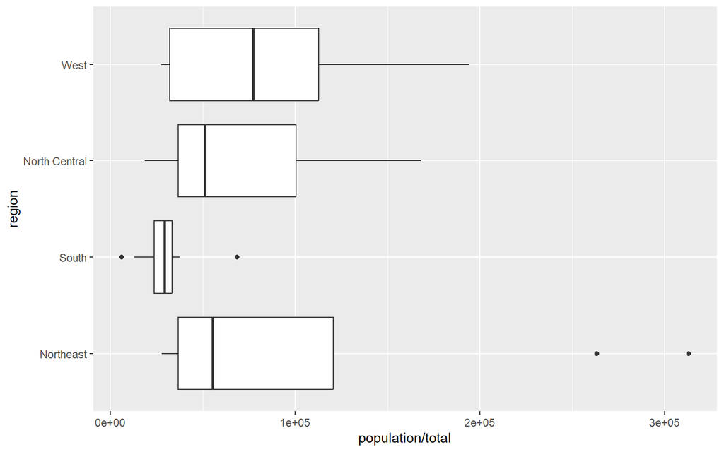

```r
ggplot(murders) +
  geom_boxplot(aes(population/total, region))
```

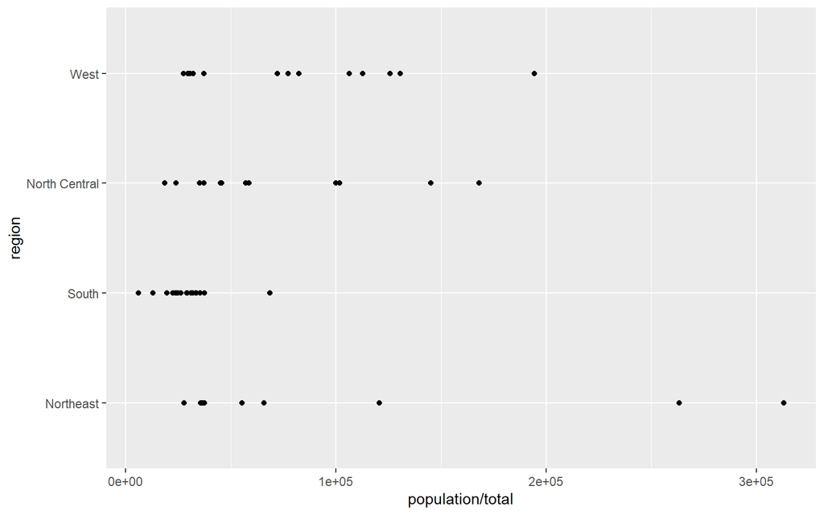

```r
# Using geom_point is closer to what we want, but the "dense" areas still don't jump out quite as much as they could, and overlap is an issue.

ggplot(murders) +
  geom_point(aes(population/total, region))
```

**Solution:** Beeswarm plots!

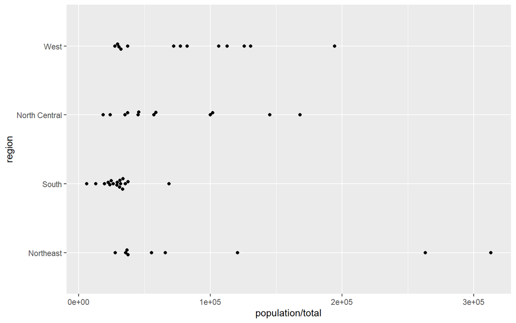

```r
library(ggbeeswarm)

ggplot(murders) +
  geom_beeswarm(aes(population/total, region))
```

Beeswarm plots implement a more extreme version of “jittering”, where the distance of the points above or below their region’s center line is arbitrary; it merely forces points outward where they are more clustered. This allows the viewer to maintain their understanding of “one point, one observation” while still effectively emphasizing dense regions.

## Field-Specific Packages: ggsoccer

> TL;DR: The point of showing you `ggsoccer` is not that we will test you on `ggsoccer` specifically, but to show you that there is probably a ggplot-friendly, specialized visualization package out there for whatever your interest is!

When I [Cameron] took this class in Spring 2022, I was interested in making soccer visualizations, especially annotating on-pitch events. However, I had no idea how to create a soccer pitch with ggplot2, and certainly didn’t want to annotate all the lines myself.

My code from Spring 2022 is below; I could figure out how to plot the locations of a player’s shot attempts, but without the pitch annotated, this is impossible to make sense of.

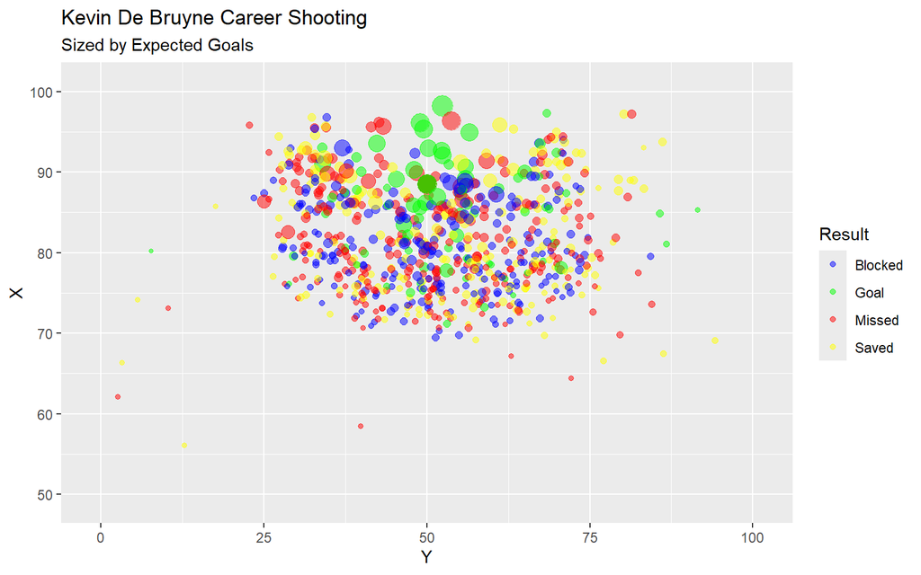

```r
library(understatr)
library(ggsoccer)

KDBShots = get_player_shots(447) # Scrape the shot locations of Kevin De Bruyne (my favorite player) from the public site understat.com
KDBShots$X = KDBShots$X * 100
KDBShots$Y = KDBShots$Y * 100
KDBShots$Result = recode(KDBShots$result, BlockedShot = "Blocked", MissedShots = "Missed", SavedShot = "Saved", ShotOnPost = "Missed")

ggplot(KDBShots) +
  geom_point(aes(x=X,y=Y,size=xG,col=Result), alpha = 0.5) +
  scale_color_manual(values = c("blue", "green", "red", "yellow", "purple")) +
  coord_flip(xlim = c(49, 101),
             ylim = c(-1, 101)) +
  guides(size = "none") +
  ggtitle(label = "Kevin De Bruyne Career Shooting", subtitle = "Sized by Expected Goals")
```

However, two simple lines of `ggsoccer` code later, and this plot becomes way easier to make sense of.

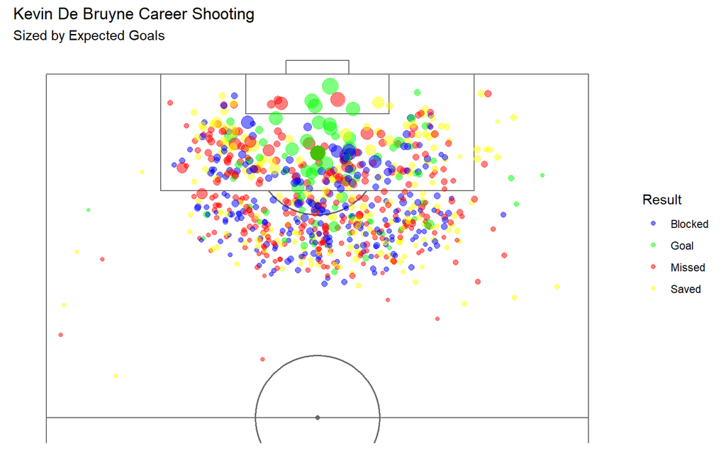

```r
ggplot(KDBShots) +
  annotate_pitch() +
  theme_pitch() +
  geom_point(aes(x=X,y=Y,size=xG,col=Result), alpha = 0.5) +
  scale_color_manual(values = c("blue", "green", "red", "yellow", "purple")) +
  coord_flip(xlim = c(49, 101),
             ylim = c(-1, 101)) +
  guides(size = "none") +
  ggtitle(label = "Kevin De Bruyne Career Shooting", subtitle = "Sized by Expected Goals")
```

The main takeaway here: No matter if you’re interested in another sport or another field entirely, it’s likely that there’s a ggplot-friendly, specialized package out there for you, that’s just a little internet digging away!